# Stock Price Analysis using Linear Regression

#### The stock market is known to be a complex adaptive system that is difficult to predict due to the large number of factors that determine the day to day price changes. We do this in machine learning through regression which tries to determine the relationship between a dependent variable and one or more independent variables. Here, the independent variables are the features and the dependent variable that we would like to predict is the price.

```python
#importing the libraries
import pandas as pd
import numpy as np
from sklearn import linear_model
import matplotlib.pyplot as plt
dataset=pd.read_csv("C:\\Users\\DELL\\stock.csv")  #path of the data set
dates = []
prices = []
dates=dataset.iloc[:,[0]].values                   #take only those independent features which we have to use in our model
prices=dataset.iloc[:,[1]].values                  #take only those dependent features which we have to use in our model
```

#### We will be predicting the future price of stock using simple linear regression using the previous stock price. The data that we will be using is real data obtained internet saved to a CSV file

```python
dataset   #dataset contain data of the csv file
```

|  | 26 | 708.58 |
| --- | --- | --- |
| 0 | 25 | 700.01 |
| 1 | 24 | 688.92 |
| 2 | 23 | 701.45 |
| 3 | 22 | 707.45 |
| 4 | 19 | 695.03 |
| 5 | 18 | 710.00 |
| 6 | 17 | 699.00 |
| 7 | 16 | 692.98 |
| 8 | 12 | 690.26 |
| 9 | 11 | 675.00 |
| 10 | 10 | 686.86 |
| 11 | 9 | 672.32 |
| 12 | 8 | 667.85 |
| 13 | 5 | 703.87 |
| 14 | 4 | 722.81 |
| 15 | 3 | 770.22 |
| 16 | 2 | 784.50 |
| 17 | 1 | 750.46 |

#### In the above dataset, we have the prices at which the stock opened from date 1 – date 26. Using this data, we will try to predict the price at which the stock will open on date 29.

```python
dates  #independent veriable
```

```
array([[25],
       [24],
       [23],
       [22],
       [19],
       [18],
       [17],
       [16],
       [12],
       [11],
       [10],
       [ 9],
       [ 8],
       [ 5],
       [ 4],
       [ 3],
       [ 2],
       [ 1]], dtype=int64)
```

```python
prices #dependent veriable
```

```
array([[700.01],
       [688.92],
       [701.45],
       [707.45],
       [695.03],
       [710.  ],
       [699.  ],
       [692.98],
       [690.26],
       [675.  ],
       [686.86],
       [672.32],
       [667.85],
       [703.87],
       [722.81],
       [770.22],
       [784.5 ],
       [750.46]])
```

```python
dates = np.reshape(dates,(len(dates),1)) #reshaping the dates array
prices = np.reshape(prices,(len(prices),1)) #reshaping the price array
```

```python
dates
```

```
array([[25],
       [24],
       [23],
       [22],
       [19],
       [18],
       [17],
       [16],
       [12],
       [11],
       [10],
       [ 9],
       [ 8],
       [ 5],
       [ 4],
       [ 3],
       [ 2],
       [ 1]], dtype=int64)
```

```python
prices
```

```
array([[700.01],
       [688.92],
       [701.45],
       [707.45],
       [695.03],
       [710.  ],
       [699.  ],
       [692.98],
       [690.26],
       [675.  ],
       [686.86],
       [672.32],
       [667.85],
       [703.87],
       [722.81],
       [770.22],
       [784.5 ],
       [750.46]])
```

```python
from sklearn.linear_model import LinearRegression #import the linerregression class
regression=LinearRegression()                     #make a class object
regression.fit(dates,prices)                      #fit the data set
```

```
LinearRegression(copy_X=True, fit_intercept=True, n_jobs=1, normalize=False)
```

```python
predicted_price =regression.predict(29)           #predicting price on a required date
predicted_price, coefficient, constant =predicted_price =predicted_price[0][0],regression.coef_[0][0] ,regression.intercept_[0]

print(predicted_price)
```

```
(675.1892774200091, -1.9303174281223061, 731.168482835556)
```

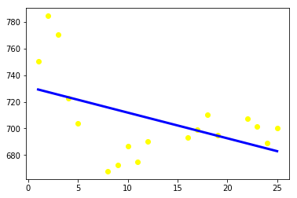

```python
plt.scatter(dates,prices,color='yellow')
plt.plot(dates,regression.predict(dates),color='blue',linewidth=3)
plt.show()
```

#### Now, we are goning to calculate the R^2 value to see how the data is fitted .

#### R-squared is a statistical measure of how close the data are to the fitted regression line. It is also known as the coefficient of determinatio.R-squared is always between 0 and 100%.

```python
#calculating total sum of squares
avg=0
for x in range(0,L):
    avg+=prices[x][0]
avg=avg/L
ssto=0
for x in range(0,L):
    ssto+=(prices[x][0]-avg)**2
print("SSTO :",ssto)
```

```
SSTO : 17413.677894444445
```

```python
#calculating error sum of squares
sse=0
for x in range(0,L):
    sse+=(prices[x][0]-regression.predict(dates[x][0]))**2
sse=sse[0][0]
print("SSE :",sse)
```

```
SSE : 13331.293534049993
```

```python
#calculate r squared
r_s=1-(sse/ssto)
r_s=r_s*100
print(r_s,"%")
```

```
23.44355043857146 %
```

#### R-squared does not indicate whether a regression model is adequate. You can have a low R-squared value for a good model, or a high R-squared value for a model that does not fit the data!

```python
print ("The stock open price for 29th day is: $",str(predicted_price))
print ("The regression coefficient is ",str(coefficient),", and the constant is ", str(constant))
print ("the relationship equation between dates and prices is: price = ",str(coefficient),"* date + ",str(constant))
```

```
The stock open price for 29th day is: $ (675.1892774200091, -1.9303174281223061, 731.168482835556)
The regression coefficient is  -1.9303174281223061 , and the constant is  731.168482835556
the relationship equation between dates and prices is: price =  -1.9303174281223061 * date +  731.168482835556
```

#### Here ,i am using a simple dataset ,the dataset can be more complex on containing different parameters .There are many more methods to predict stock price like -Multiple regression ,SVM,Tensor Flow,etc linear regression is one of basic method to predict future stock price.